# Deep Multimodal Teaching Analytics paper – Evaluation Harness

Abstract

This template shows the different kinds of performance evaluations at different levels that we want to do on the models we propose for the paper. This includes attempting to do generalistic models (that work for all teachers) and personalized ones (that work with just one teacher).

# How to use it

Just make a copy of this file, insert your FEATURE SELECTION and your MODEL TRAINING where comments mark it so, and run/knit the whole document!

# Loading the data

```r
library("tidyverse")
library(randomForest)
library(AUC)
library(caret)
library(e1071)



processeddatadir <- "../data/processed"
datafile <- paste(processeddatadir, "completeDataset.csv", sep = .Platform$file.sep)
gzdatafile <- paste(processeddatadir, "completeDataset.csv.gz", sep = .Platform$file.sep)
fulldata <- data.frame()
if (file.exists(datafile)) {
    fulldata <- read.csv(datafile)
} else if (file.exists(gzdatafile)) {
    fulldata <- read.csv(gzfile(datafile))
} else {
    stop("Data not available in the data/processed folder")
}


# table(fulldata$session, fulldata$Activity.win, useNA = 'always')
# table(fulldata$session, fulldata$Social.win, useNA = 'always')

# We only look for predicting 4 states of activity and 3 of social, the rest
# (incl.NA) we bunch in 'Other'
fulldata$Activity.clean <- ifelse(is.na(as.character(fulldata$Activity.win)) |
    as.character(fulldata$Activity.win) == "OFF" | as.character(fulldata$Activity.win) ==
    "TDT" | as.character(fulldata$Activity.win) == "TEC", "Other", as.character(fulldata$Activity.win))

fulldata$Social.clean <- ifelse(is.na(as.character(fulldata$Social.win)), "Other",
    as.character(fulldata$Social.win))

# table(fulldata$session, fulldata$Activity.clean, useNA = 'always')
# table(fulldata$session, fulldata$Social.clean, useNA = 'always')

names(fulldata)[7562:7563] <- c("Activity", "Social")
fulldata <- fulldata[, -c(1, 4, 5, 6)]
fulldata$Activity <- factor(fulldata$Activity)
fulldata$Social <- factor(fulldata$Social)
```

# Dataset overview

Both the training and testing datasets have the following general structure:

- ‘’Rows’’ represent the features of each 10s window (overlapping/sliding 5s), ordered by `session` ID and its `timestamp` (in ms)
- ‘’Columns’’ are the features themselves (they have more-or-less-cryptic column names), up to 7559 of them!
  - [,2]: ’‘timestamp’’ within the session (in ms)
  - [,3:12]: ‘’eyetracking’’ features (mean/sd pupil diameter, nr. of long fixations, avg. saccade speed, fixation duration, fixation dispersion, saccade duration, saccade amplitude, saccade length, saccade velocity)
  - [,13:152]: ‘’accelerometer’’ features, including X, Y, Z (mean, sd, max, min, median, and 30 FFT coefficients of each of them) and jerk (mean, sd, max, min, median, and 30 FFT coefficients of each of it)
  - [,153:6557]: ‘’audio’’ features extracted from an audio snippet of the 10s window, using openSMILE. Includes features about whether there is someone speaking (153:163), emotion recognition models (164:184), and brute-force audio spectrum features and characteristics used in various audio recognition challenges/tasks (185:6557)
  - [,6558:7557]: ‘’video’’ features extracted from an image taken in the middle of the window (the 1000 values of the last layer when passing the immage through a VGG pre-trained model)
  - [,7558:7559]: ‘’Activity,Social’’ labels we want to predict

```r
########## FEATURE SELECTION/TRANSFORMATION
########## ################################################ Perform here other
########## transformations (e.g., dimensionality reduction via PCA, feature
########## selection...)

# For exampleTake only the eyetracking part of the dataset
data <- fulldata[, c(1:12, 7558:7559)]
# data <- fulldata # For full dataset
```

# General models (multi-teacher)

How good are we at building a model that is able to detect the labels for multiple teachers?

## Leave one session out

```r
sessions <- unique(data$session)

# Models and performances
perfA <- list(label = character(), models = list(), cms = list(), aucs = numeric())
for (i in 1:length(sessions)) {
    s <- sessions[i]
    # print(s)
    test <- data %>% filter(session == s)
    train <- data %>% filter(session != s)

    # Setup the seeds and training
    set.seed(123)
    input <- train %>% select(-session, -timestamp, -Social) %>% filter(complete.cases(.))

    ########## TRAINING CODE ################################################

    fitA <- randomForest(Activity ~ ., data = input, importance = TRUE)

    #########################################################################
    test$Activity.pred = predict(fitA, test)
    cmA <- confusionMatrix(test$Activity.pred, test$Activity)
    # print(cmA) varImpPlot(fitA, scale=FALSE)
    aucA <- NA
    aucA <- tryCatch(auc(roc(test$Activity.pred, test$Activity)), error = function(e) {
        print(paste("could not calculate AUC for", as.character(s)))
        return(NA)
    })
    # print(aucA)
    perfA$label[[i]] <- as.character(s)
    perfA$models[[i]] <- fitA
    perfA$cms[[i]] <- cmA
    perfA$aucs[[i]] <- aucA

}
print("Predicting Activity...")
```

```
[1] "Predicting Activity..."
```

```r
print(paste("Avg AUC", mean(perfA$aucs)))
```

```
[1] "Avg AUC 0.537232883673687"
```

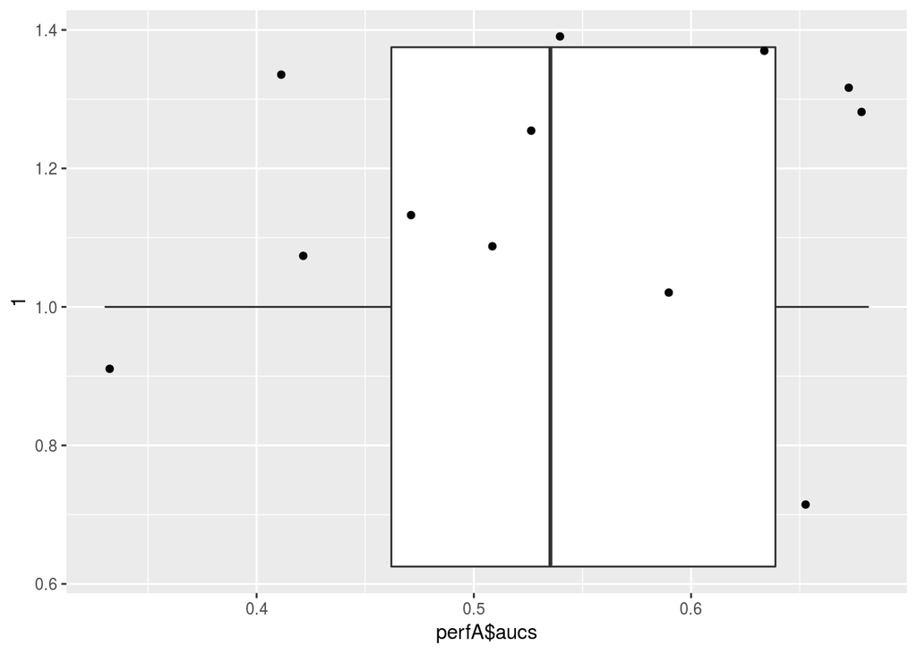

```r
qplot(perfA$aucs, x = 1, geom = "boxplot") + coord_flip() + geom_jitter()
```

```r
kps <- sapply(perfA$cms, function(x) {
    x$overall["Kappa"]
})
print(paste("Avg Kappa", mean(kps)))
```

```
[1] "Avg Kappa 0.151500257245444"
```

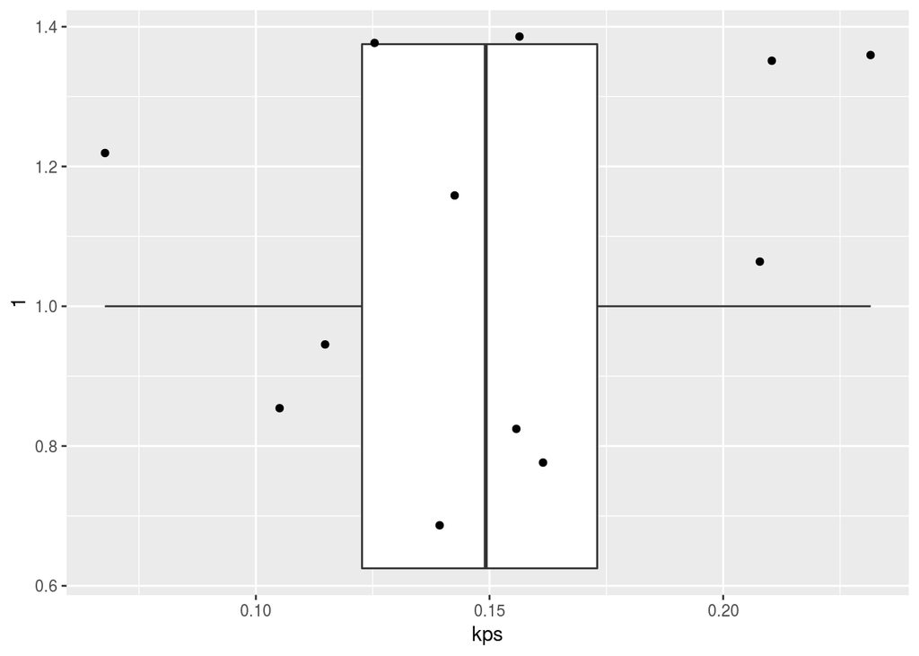

```r
qplot(kps, x = 1, geom = "boxplot") + coord_flip() + geom_jitter()
```

```r
accs <- sapply(perfA$cms, function(x) {
    x$overall["Accuracy"]
})
print(paste("Avg Accuracy", mean(accs)))
```

```
[1] "Avg Accuracy 0.380578636885172"
```

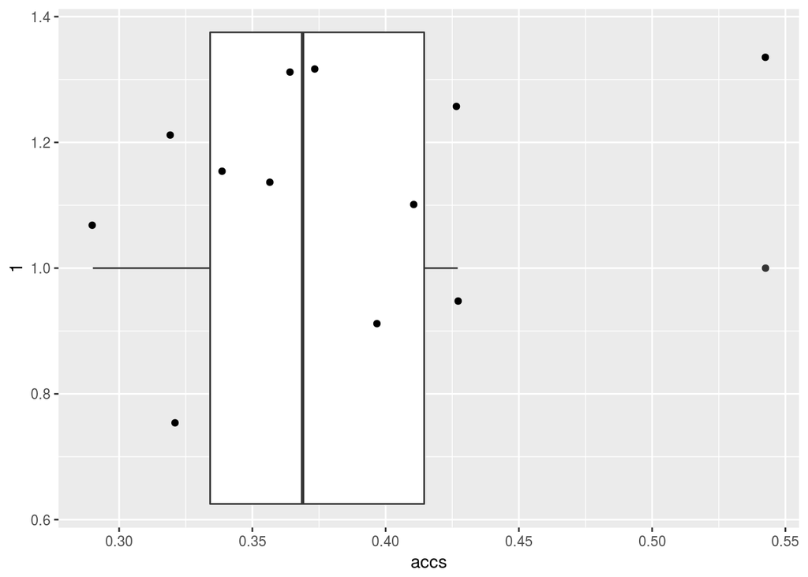

```r
qplot(accs, x = 1, geom = "boxplot") + coord_flip() + geom_jitter()
```

```r
# Models and performances
perfS <- list(label = character(), models = list(), cms = list(), aucs = numeric())
for (i in 1:length(sessions)) {
    s <- sessions[i]
    # print(s)
    test <- data %>% filter(session == s)
    train <- data %>% filter(session != s)

    # Setup the seeds and training
    set.seed(456)
    input <- train %>% select(-session, -timestamp, -Activity) %>% filter(complete.cases(.))

    ########## TRAINING CODE ################################################

    fitS <- randomForest(Social ~ ., data = input, importance = TRUE)

    ########################################################################
    test$Social.pred = predict(fitS, test)
    cmS <- confusionMatrix(test$Social.pred, test$Social)
    # print(cmS) varImpPlot(fitS, scale=FALSE)
    aucS <- NA
    aucS <- tryCatch(auc(roc(test$Social.pred, test$Social)), error = function(e) {
        print(paste("could not calculate AUC for", as.character(s)))
        return(NA)
    })
    # print(aucS)
    perfS$label[[i]] <- as.character(s)
    perfS$models[[i]] <- fitS
    perfS$cms[[i]] <- cmS
    perfS$aucs[[i]] <- aucS

}
```

```
[1] "could not calculate AUC for case2-day2-session1-teacher2"
[1] "could not calculate AUC for case2-day4-session1-teacher2"
[1] "could not calculate AUC for case2-day4-session2-teacher2"
```

```r
print("Predicting Social")
```

```
[1] "Predicting Social"
```

```r
print(paste("Avg AUC", mean(perfS$aucs, na.rm = T)))
```

```
[1] "Avg AUC 0.661632049161734"
```

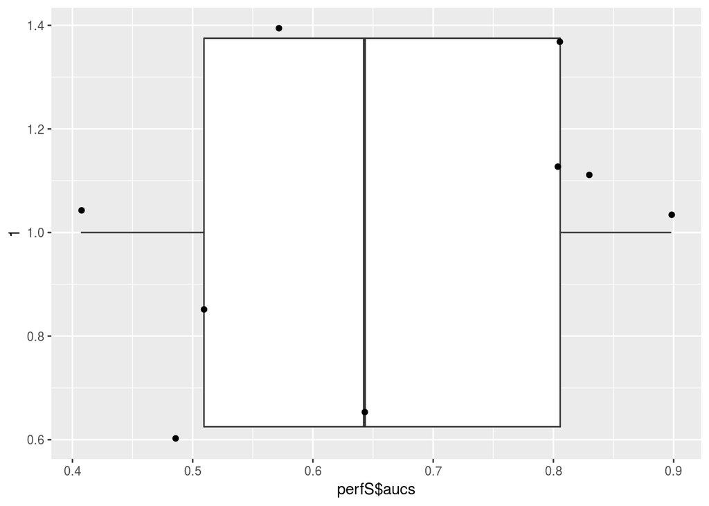

```r
qplot(perfS$aucs, x = 1, geom = "boxplot") + coord_flip() + geom_jitter()
```

```r
kps <- sapply(perfS$cms, function(x) {
    x$overall["Kappa"]
})
print(paste("Avg Kappa", mean(kps)))
```

```
[1] "Avg Kappa 0.335620417517101"
```

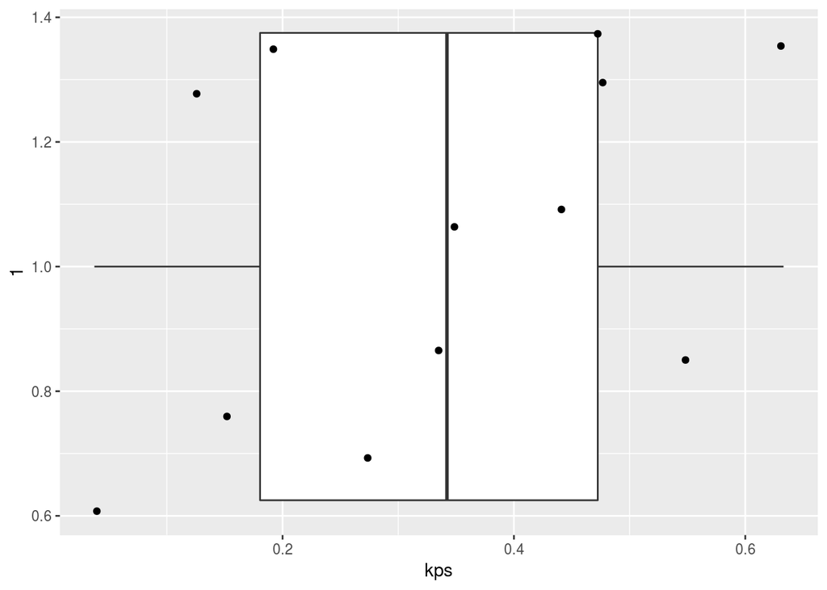

```r
qplot(kps, x = 1, geom = "boxplot") + coord_flip() + geom_jitter()
```

```r
accs <- sapply(perfS$cms, function(x) {
    x$overall["Accuracy"]
})
print(paste("Avg Accuracy", mean(accs)))
```

```
[1] "Avg Accuracy 0.656432344778251"
```

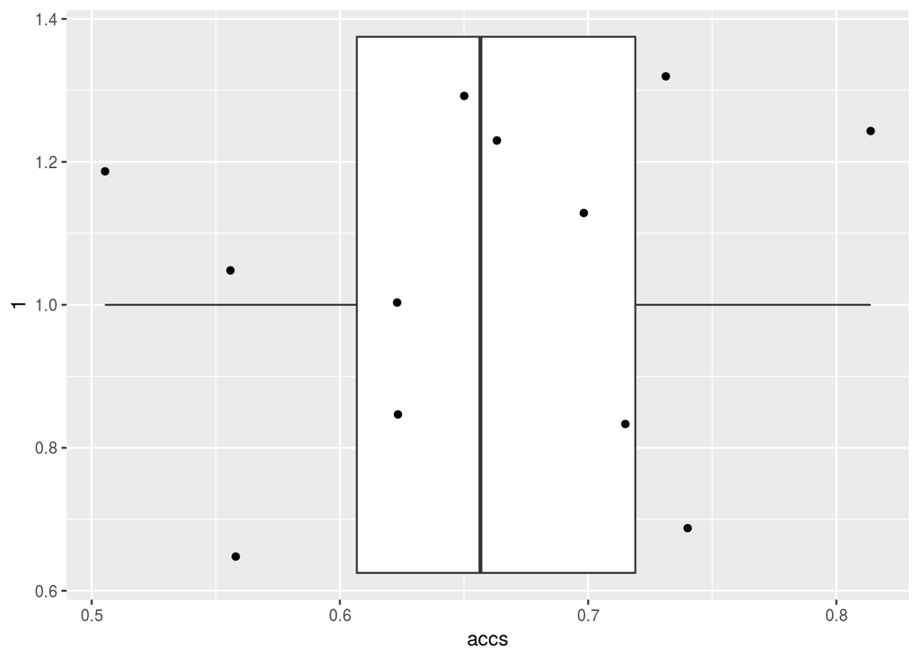

```r
qplot(accs, x = 1, geom = "boxplot") + coord_flip() + geom_jitter()
```

## Leave one teacher out (train on one, test on the other)

```r
teachers <- c("teacher1", "teacher2")
data <- data %>% mutate(teacher = ifelse(grepl("teacher1", session, fixed = T),
    "teacher1", "teacher2"))
# Models and performances
perfA2 <- list(label = character(), models = list(), cms = list(), aucs = numeric())
for (i in 1:length(teachers)) {
    s <- teachers[i]
    # print(s)
    test <- data %>% filter(teacher == s)
    train <- data %>% filter(teacher != s)

    # Setup the seeds and training
    set.seed(123)
    input <- train %>% select(-session, -timestamp, -Social, -teacher) %>% filter(complete.cases(.))

    ########## TRAINING CODE ################################################

    fitA <- randomForest(Activity ~ ., data = input, importance = TRUE)

    #########################################################################
    test$Activity.pred = predict(fitA, test)
    cmA <- confusionMatrix(test$Activity.pred, test$Activity)
    # print(cmA) varImpPlot(fitA, scale=FALSE)
    aucA <- NA
    aucA <- tryCatch(auc(roc(test$Activity.pred, test$Activity)), error = function(e) {
        print(paste("could not calculate AUC for", as.character(s)))
        return(NA)
    })
    # print(aucA)
    perfA2$label[[i]] <- as.character(s)
    perfA2$models[[i]] <- fitA
    perfA2$cms[[i]] <- cmA
    perfA2$aucs[[i]] <- aucA

}
print("Predicting Activity...")
```

```
[1] "Predicting Activity..."
```

```r
print(paste("Avg AUC", mean(perfA2$aucs)))
```

```
[1] "Avg AUC 0.399937826703411"
```

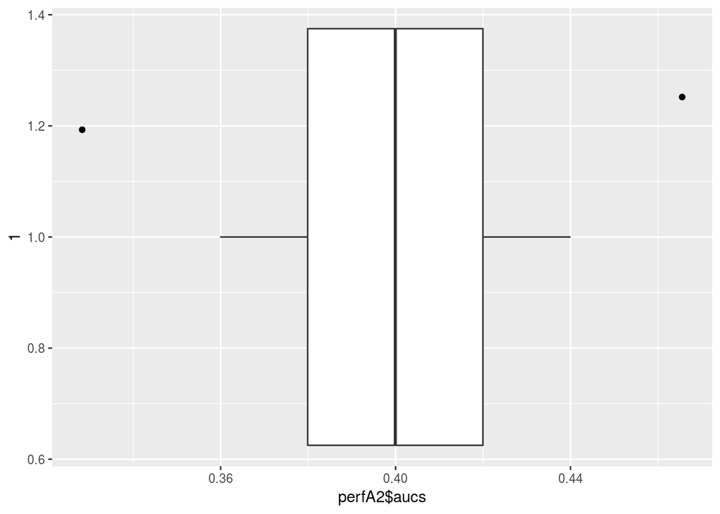

```r
qplot(perfA2$aucs, x = 1, geom = "boxplot") + coord_flip() + geom_jitter()
```

```r
kps <- sapply(perfA2$cms, function(x) {
    x$overall["Kappa"]
})
print(paste("Avg Kappa", mean(kps)))
```

```
[1] "Avg Kappa 0.093592381843176"
```

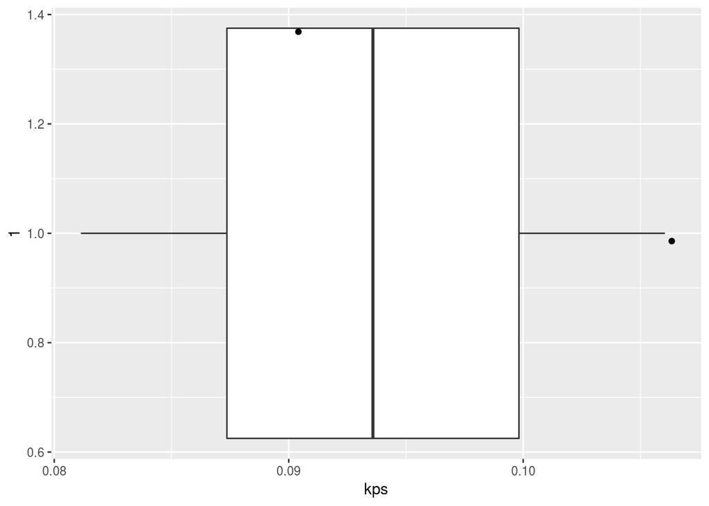

```r
qplot(kps, x = 1, geom = "boxplot") + coord_flip() + geom_jitter()
```

```r
accs <- sapply(perfA2$cms, function(x) {
    x$overall["Accuracy"]
})
print(paste("Avg Accuracy", mean(accs)))
```

```
[1] "Avg Accuracy 0.318057639550242"
```

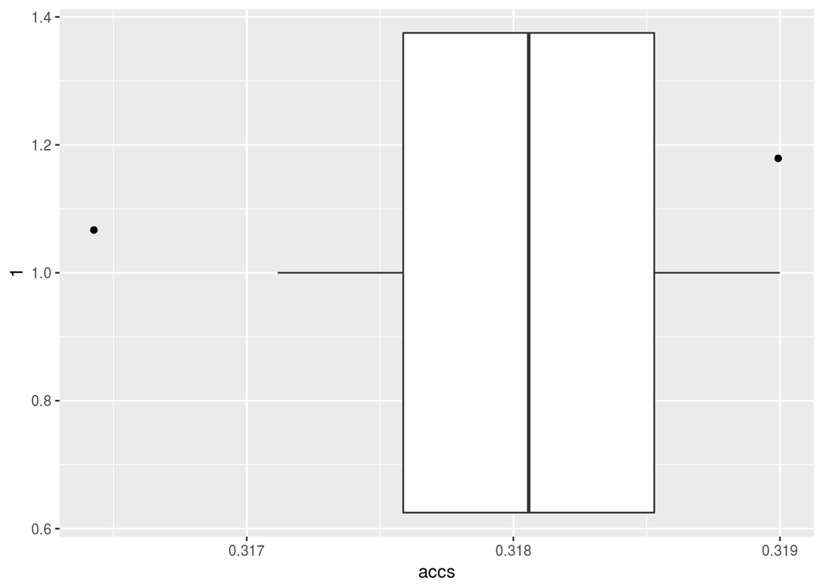

```r
qplot(accs, x = 1, geom = "boxplot") + coord_flip() + geom_jitter()
```

```r
# Models and performances
perfS2 <- list(label = character(), models = list(), cms = list(), aucs = numeric())
for (i in 1:length(teachers)) {
    s <- teachers[i]
    # print(s)
    test <- data %>% filter(teacher == s)
    train <- data %>% filter(teacher != s)

    # Setup the seeds and training
    set.seed(456)
    input <- train %>% select(-session, -timestamp, -Activity, -teacher) %>%
        filter(complete.cases(.))

    ########## TRAINING CODE ################################################

    fitS <- randomForest(Social ~ ., data = input, importance = TRUE)

    ########################################################################
    test$Social.pred = predict(fitS, test)
    cmS <- confusionMatrix(test$Social.pred, test$Social)
    # print(cmS) varImpPlot(fitS, scale=FALSE)
    aucS <- NA
    aucS <- tryCatch(auc(roc(test$Social.pred, test$Social)), error = function(e) {
        print(paste("could not calculate AUC for", as.character(s)))
        return(NA)
    })
    # print(aucS)
    perfS2$label[[i]] <- as.character(s)
    perfS2$models[[i]] <- fitS
    perfS2$cms[[i]] <- cmS
    perfS2$aucs[[i]] <- aucS

}
print("Predicting Social")
```

```
[1] "Predicting Social"
```

```r
print(paste("Avg AUC", mean(perfS2$aucs, na.rm = T)))
```

```
[1] "Avg AUC 0.520870838715143"
```

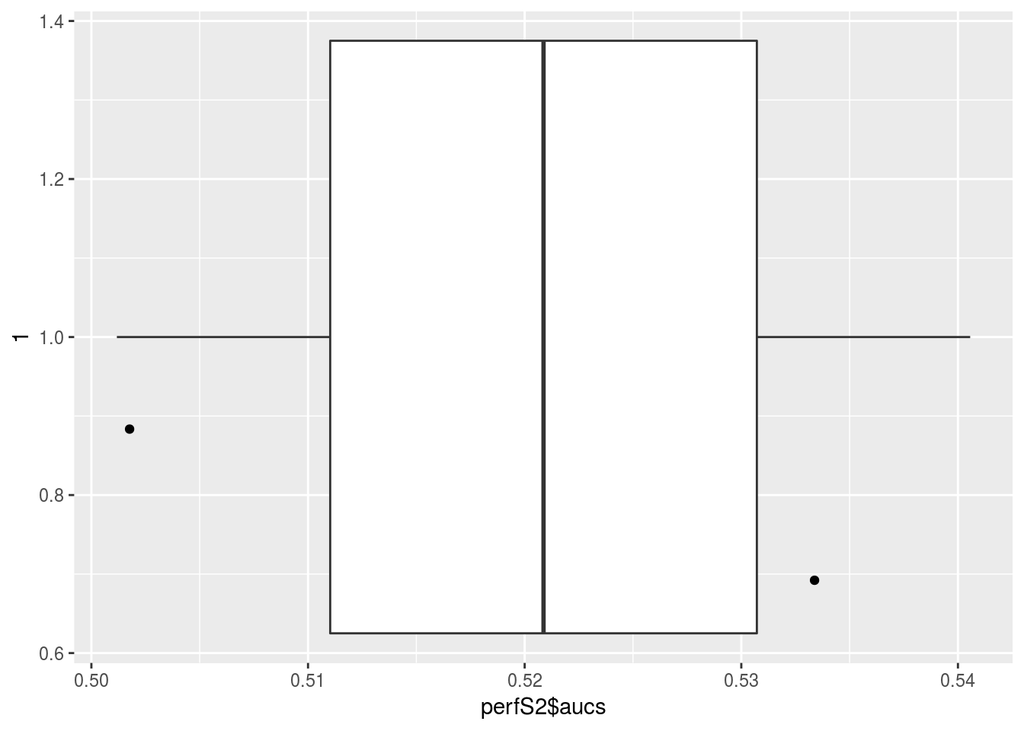

```r
qplot(perfS2$aucs, x = 1, geom = "boxplot") + coord_flip() + geom_jitter()
```

```r
kps <- sapply(perfS2$cms, function(x) {
    x$overall["Kappa"]
})
print(paste("Avg Kappa", mean(kps)))
```

```
[1] "Avg Kappa 0.065164900730957"
```

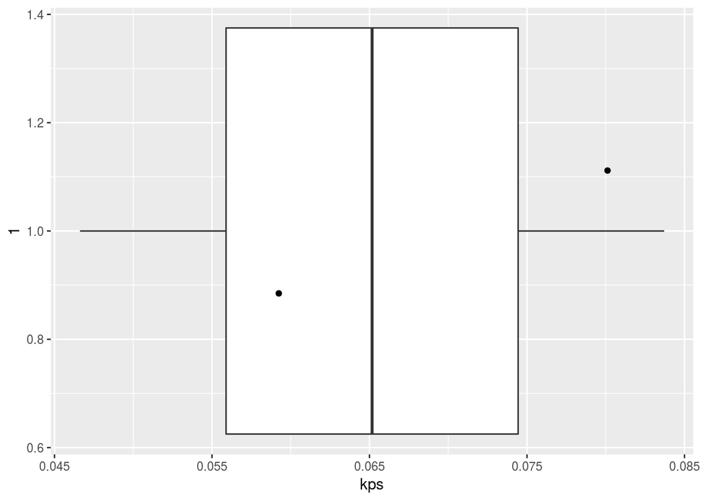

```r
qplot(kps, x = 1, geom = "boxplot") + coord_flip() + geom_jitter()
```

```r
accs <- sapply(perfS2$cms, function(x) {
    x$overall["Accuracy"]
})
print(paste("Avg Accuracy", mean(accs)))
```

```
[1] "Avg Accuracy 0.395375853852215"
```

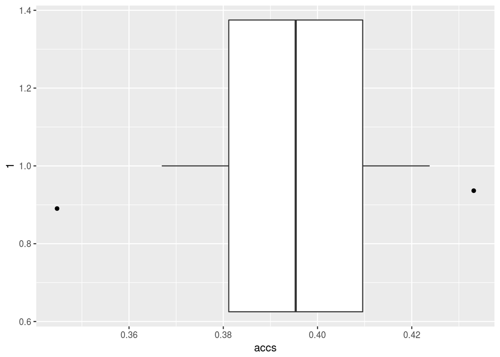

```r
qplot(accs, x = 1, geom = "boxplot") + coord_flip() + geom_jitter()
```

# Personalized models (trained and tested with data from ONE teacher)

## Leave one session out

```r
# sessions and teachers already exist

# Models and performances
perfA3 <- list(label = character(), models = list(), cms = list(), aucs = numeric())
counter <- 1
for (j in 1:length(teachers)) {
    t <- teachers[j]
    partdata <- data %>% filter(teacher == t)
    # We train/test on the data for one teacher
    partsessions <- unique(partdata$session)
    for (i in 1:length(partsessions)) {
        s <- partsessions[i]
        # print(s)
        test <- partdata %>% filter(session == s)
        train <- partdata %>% filter(session != s)

        # Setup the seeds and training
        set.seed(123)
        input <- train %>% select(-session, -timestamp, -Social, -teacher) %>%
            filter(complete.cases(.))

        ########## TRAINING CODE ################################################

        fitA <- randomForest(Activity ~ ., data = input, importance = TRUE)

        #########################################################################
        test$Activity.pred = predict(fitA, test)
        cmA <- confusionMatrix(test$Activity.pred, test$Activity)
        # print(cmA) varImpPlot(fitA, scale=FALSE)
        aucA <- NA
        aucA <- tryCatch(auc(roc(test$Activity.pred, test$Activity)), error = function(e) {
            print(paste("could not calculate AUC for", as.character(s)))
            return(NA)
        })
        # print(aucA)
        perfA3$label[[counter]] <- as.character(s)
        perfA3$models[[counter]] <- fitA
        perfA3$cms[[counter]] <- cmA
        perfA3$aucs[[counter]] <- aucA
        counter <- counter + 1
    }

}

print("Predicting Activity...")
```

```
[1] "Predicting Activity..."
```

```r
print(paste("Avg AUC", mean(perfA3$aucs)))
```

```
[1] "Avg AUC 0.536775710688433"
```

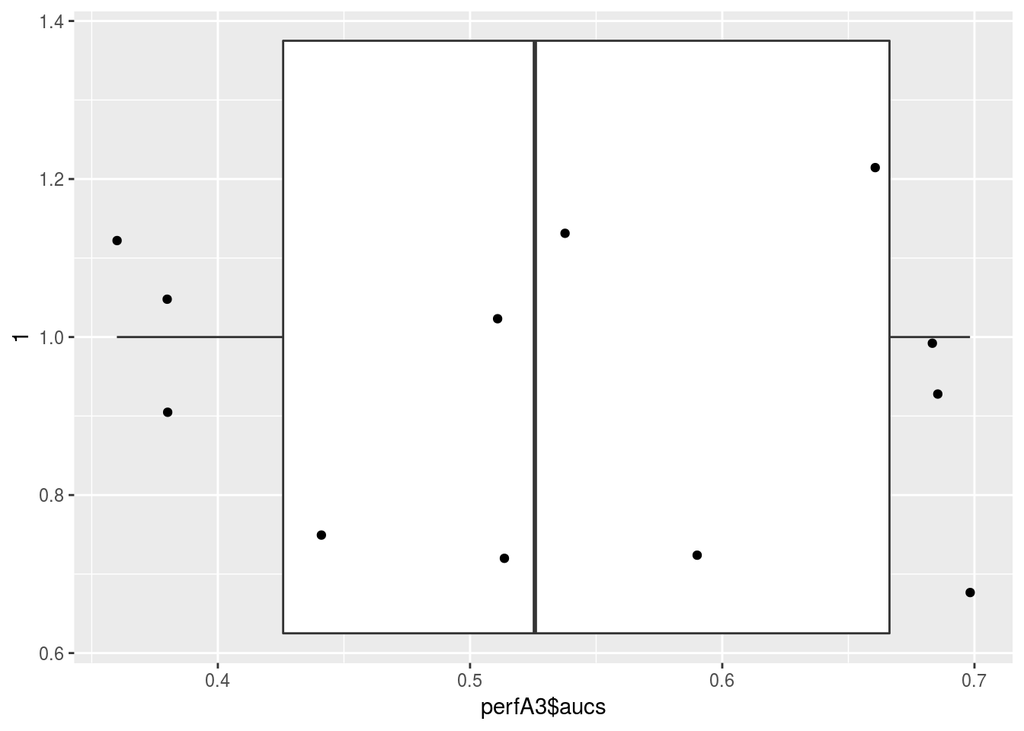

```r
qplot(perfA3$aucs, x = 1, geom = "boxplot") + coord_flip() + geom_jitter()
```

```r
kps <- sapply(perfA3$cms, function(x) {
    x$overall["Kappa"]
})
print(paste("Avg Kappa", mean(kps)))
```

```
[1] "Avg Kappa 0.158535380230476"
```

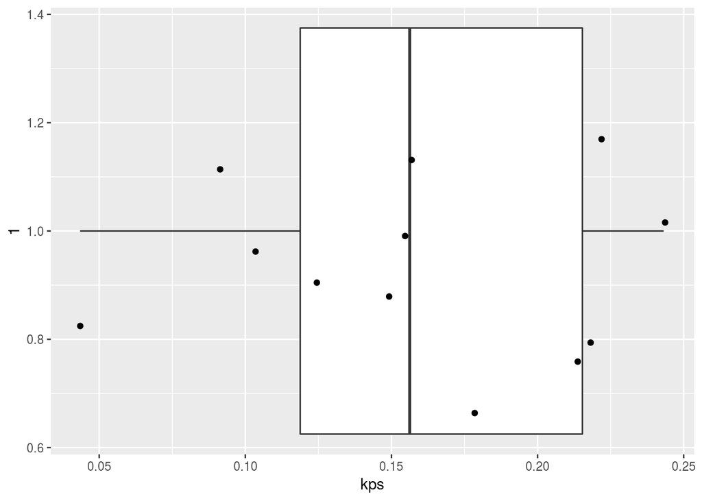

```r
qplot(kps, x = 1, geom = "boxplot") + coord_flip() + geom_jitter()
```

```r
accs <- sapply(perfA3$cms, function(x) {
    x$overall["Accuracy"]
})
print(paste("Avg Accuracy", mean(accs)))
```

```
[1] "Avg Accuracy 0.383120866935853"
```

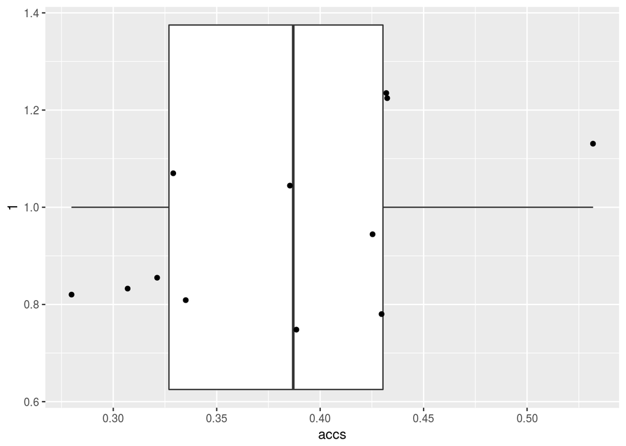

```r
qplot(accs, x = 1, geom = "boxplot") + coord_flip() + geom_jitter()
```

```r
# Models and performances
perfS3 <- list(label = character(), models = list(), cms = list(), aucs = numeric())
counter <- 1
for (j in 1:length(teachers)) {
    t <- teachers[j]
    partdata <- data %>% filter(teacher == t)
    # We train/test on the data for one teacher
    partsessions <- unique(partdata$session)
    for (i in 1:length(partsessions)) {
        s <- partsessions[i]
        # print(s)
        test <- partdata %>% filter(session == s)
        train <- partdata %>% filter(session != s)


        # Setup the seeds and training
        set.seed(456)
        input <- train %>% select(-session, -timestamp, -Activity, -teacher) %>%
            filter(complete.cases(.))

        ########## TRAINING CODE ################################################

        fitS <- randomForest(Social ~ ., data = input, importance = TRUE)

        ########################################################################
        test$Social.pred = predict(fitS, test)
        cmS <- confusionMatrix(test$Social.pred, test$Social)
        # print(cmS) varImpPlot(fitS, scale=FALSE)
        aucS <- NA
        aucS <- tryCatch(auc(roc(test$Social.pred, test$Social)), error = function(e) {
            print(paste("could not calculate AUC for", as.character(s)))
            return(NA)
        })
        # print(aucS)
        perfS3$label[[counter]] <- as.character(s)
        perfS3$models[[counter]] <- fitS
        perfS3$cms[[counter]] <- cmS
        perfS3$aucs[[counter]] <- aucS
        counter <- counter + 1

    }
}
```

```
[1] "could not calculate AUC for case2-day2-session1-teacher2"
[1] "could not calculate AUC for case2-day4-session1-teacher2"
[1] "could not calculate AUC for case2-day4-session2-teacher2"
```

```r
print("Predicting Social")
```

```
[1] "Predicting Social"
```

```r
print(paste("Avg AUC", mean(perfS3$aucs, na.rm = T)))
```

```
[1] "Avg AUC 0.642829351183892"
```

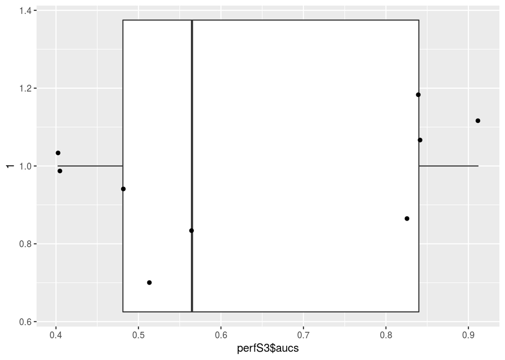

```r
qplot(perfS3$aucs, x = 1, geom = "boxplot") + coord_flip() + geom_jitter()
```

```r
kps <- sapply(perfS3$cms, function(x) {
    x$overall["Kappa"]
})
print(paste("Avg Kappa", mean(kps)))
```

```
[1] "Avg Kappa 0.364597488972461"
```

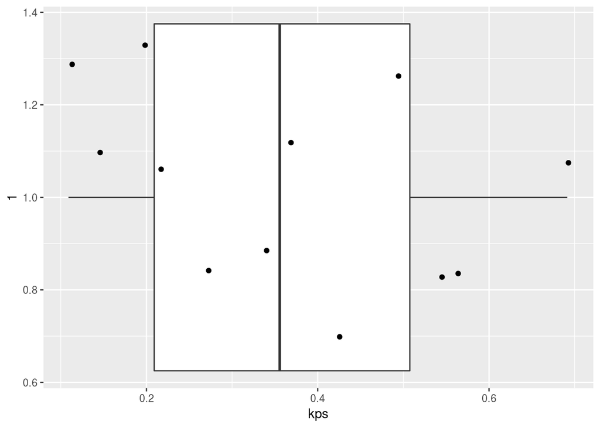

```r
qplot(kps, x = 1, geom = "boxplot") + coord_flip() + geom_jitter()
```

```r
accs <- sapply(perfS3$cms, function(x) {
    x$overall["Accuracy"]
})
print(paste("Avg Accuracy", mean(accs)))
```

```
[1] "Avg Accuracy 0.668405308468777"
```

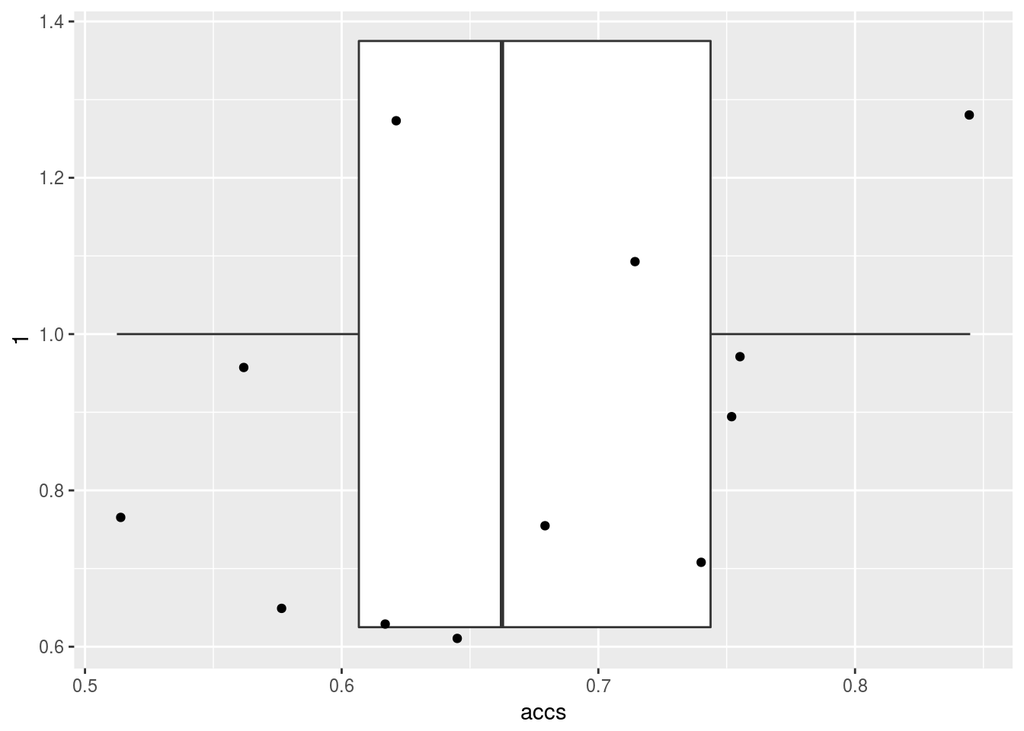

```r
qplot(accs, x = 1, geom = "boxplot") + coord_flip() + geom_jitter()
```

## Leave one situation out (only for teacher 2)

```r
# sessions and teachers already exist
data2 <- data %>% filter(teacher == "teacher2")
data2 <- data2 %>% mutate(situation = ifelse(grepl("day1", session, fixed = T),
    "day1", ifelse(grepl("day2", session, fixed = T), "day2", ifelse(grepl("day3",
        session, fixed = T), "day3", "day4"))))
situations <- unique(data2$situation)
# Models and performances
perfA4 <- list(label = character(), models = list(), cms = list(), aucs = numeric())
counter <- 1

for (i in 1:length(situations)) {
    s <- situations[i]
    # print(s)
    test <- data2 %>% filter(situation == s)
    train <- data2 %>% filter(situation != s)

    # Setup the seeds and training
    set.seed(123)
    input <- train %>% select(-session, -timestamp, -Social, -teacher, -situation) %>%
        filter(complete.cases(.))

    ########## TRAINING CODE ################################################

    fitA <- randomForest(Activity ~ ., data = input, importance = TRUE)

    #########################################################################
    test$Activity.pred = predict(fitA, test)
    cmA <- confusionMatrix(test$Activity.pred, test$Activity)
    # print(cmA) varImpPlot(fitA, scale=FALSE)
    aucA <- NA
    aucA <- tryCatch(auc(roc(test$Activity.pred, test$Activity)), error = function(e) {
        print(paste("could not calculate AUC for", as.character(s)))
        return(NA)
    })
    # print(aucA)
    perfA4$label[[counter]] <- as.character(s)
    perfA4$models[[counter]] <- fitA
    perfA4$cms[[counter]] <- cmA
    perfA4$aucs[[counter]] <- aucA
    counter <- counter + 1
}

print("Predicting Activity...")
```

```
[1] "Predicting Activity..."
```

```r
print(paste("Avg AUC", mean(perfA4$aucs)))
```

```
[1] "Avg AUC 0.597838586966665"
```

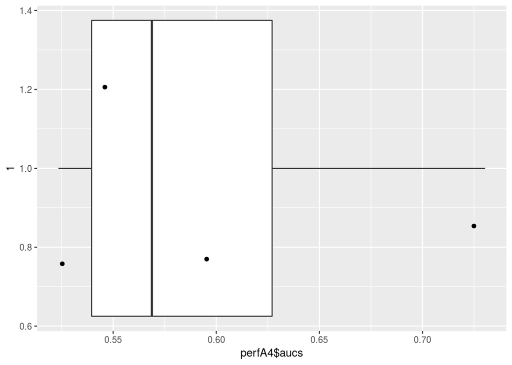

```r
qplot(perfA4$aucs, x = 1, geom = "boxplot") + coord_flip() + geom_jitter()
```

```r
kps <- sapply(perfA4$cms, function(x) {
    x$overall["Kappa"]
})
print(paste("Avg Kappa", mean(kps)))
```

```
[1] "Avg Kappa 0.114338049602946"
```

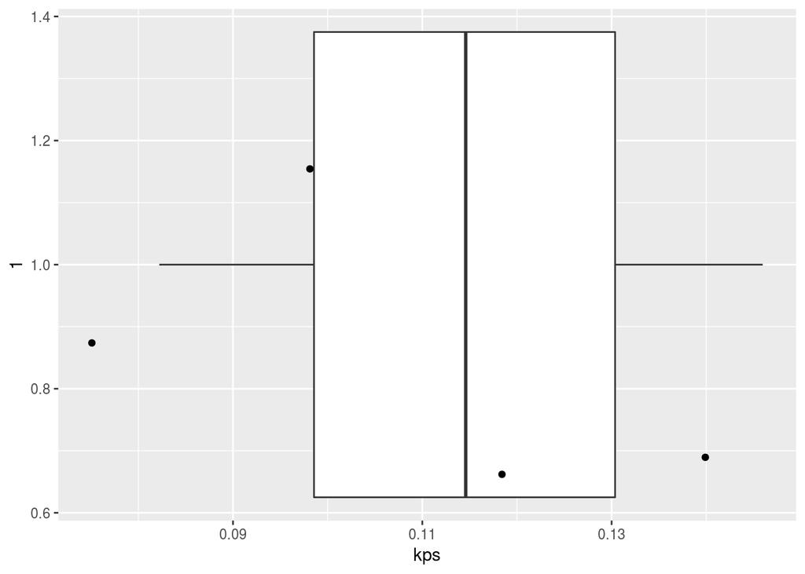

```r
qplot(kps, x = 1, geom = "boxplot") + coord_flip() + geom_jitter()
```

```r
accs <- sapply(perfA4$cms, function(x) {
    x$overall["Accuracy"]
})
print(paste("Avg Accuracy", mean(accs)))
```

```
[1] "Avg Accuracy 0.344316080818409"
```

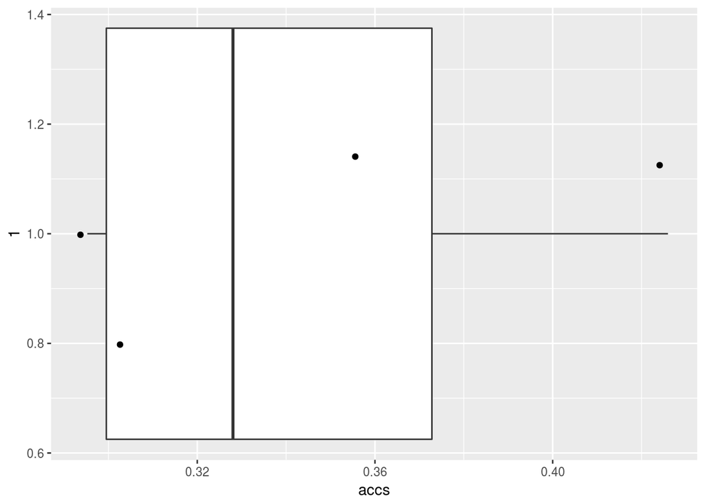

```r
qplot(accs, x = 1, geom = "boxplot") + coord_flip() + geom_jitter()
```

```r
# Models and performances
perfS4 <- list(label = character(), models = list(), cms = list(), aucs = numeric())
counter <- 1

for (i in 1:length(situations)) {
    s <- situations[i]
    # print(s)
    test <- data2 %>% filter(situation == s)
    train <- data2 %>% filter(situation != s)

    # Setup the seeds and training
    set.seed(456)
    input <- train %>% select(-session, -timestamp, -Activity, -teacher, -situation) %>%
        filter(complete.cases(.))

    ########## TRAINING CODE ################################################

    fitS <- randomForest(Social ~ ., data = input, importance = TRUE)

    ########################################################################
    test$Social.pred = predict(fitS, test)
    cmS <- confusionMatrix(test$Social.pred, test$Social)
    # print(cmS) varImpPlot(fitS, scale=FALSE)
    aucS <- NA
    aucS <- tryCatch(auc(roc(test$Social.pred, test$Social)), error = function(e) {
        print(paste("could not calculate AUC for", as.character(s)))
        return(NA)
    })
    # print(aucS)
    perfS4$label[[counter]] <- as.character(s)
    perfS4$models[[counter]] <- fitS
    perfS4$cms[[counter]] <- cmS
    perfS4$aucs[[counter]] <- aucS
    counter <- counter + 1

}
```

```
[1] "could not calculate AUC for day4"
```

```r
print("Predicting Social")
```

```
[1] "Predicting Social"
```

```r
print(paste("Avg AUC", mean(perfS4$aucs, na.rm = T)))
```

```
[1] "Avg AUC 0.491383773077762"
```

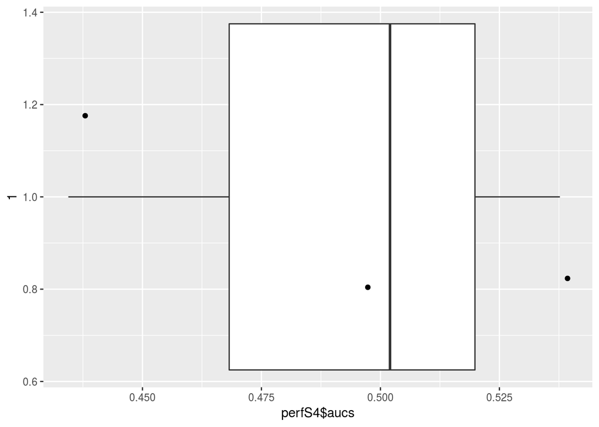

```r
qplot(perfS4$aucs, x = 1, geom = "boxplot") + coord_flip() + geom_jitter()
```

```r
kps <- sapply(perfS4$cms, function(x) {
    x$overall["Kappa"]
})
print(paste("Avg Kappa", mean(kps)))
```

```
[1] "Avg Kappa 0.207083509314877"
```

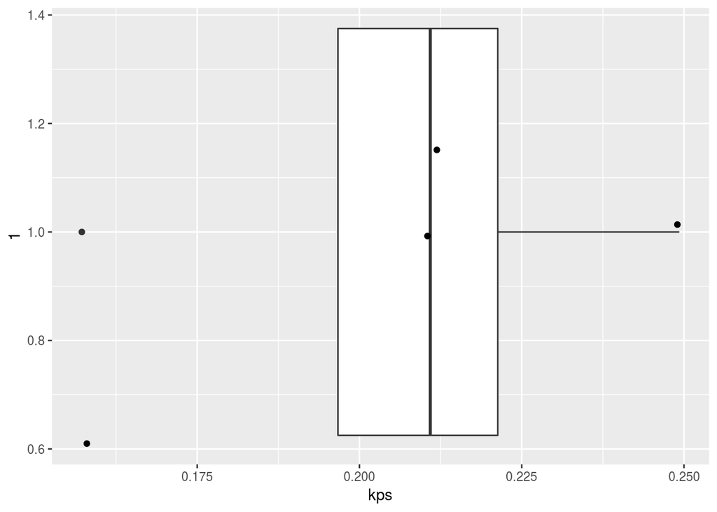

```r
qplot(kps, x = 1, geom = "boxplot") + coord_flip() + geom_jitter()
```

```r
accs <- sapply(perfS4$cms, function(x) {
    x$overall["Accuracy"]
})
print(paste("Avg Accuracy", mean(accs)))
```

```
[1] "Avg Accuracy 0.566917637842396"
```

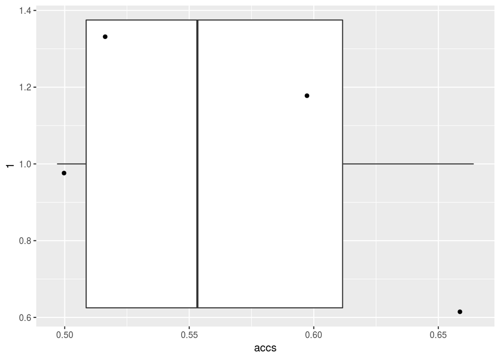

```r
qplot(accs, x = 1, geom = "boxplot") + coord_flip() + geom_jitter()
```